# Differential Expression for multiple contrasts

Lorena Pantano

2019-06-11

# set up

## Parent folder

```r
message(getwd())
```

```
## /Users/lpantano/repos/pilm/templates-rmd-de
```

## Check params

```r
library(SummarizedExperiment)
library(stringr)

# add check function
if(!file.exists(params$se_file))
    stop("se_file isn't found: ", params$se_file)

se = readRDS(params$se_file)
stopifnot(class(se) == "SummarizedExperiment" | class(se) == "RangedSummarizedExperiment")

stopifnot(sum(params$metadata %in% colnames(colData(se))) == length(params$metadata))

comparisons = str_split(params$contrast, ",")[[1]]
contrasts = lapply(comparisons, function(c){
    m = str_match(c, "(.+)\\.(.+)_vs_(.+)") %>%
        as.vector()
    if( ! m[2] %in% colnames(colData(se)))
        stop("column ", m[2],"not in colnames: ", colnames(colData(se)) )
    values = unique(colData(se)[[m[2]]])
    if(! m[3] %in% colData(se)[[m[2]]])
        stop("value ", m[3], "not in column values: ", values)
    if(! m[4] %in% colData(se)[[m[2]]])
        stop("value ", m[4], "not in column values: ", values)
    c(m[2], m[3], m[4])
})
```

## Load data

```r
# Set seed for reproducibility
set.seed(1454944673)
library(knitr)
library(ggplot2)
opts_chunk[["set"]](
    autodep = TRUE,
    bootstrap.show.code = FALSE,
    cache = params$cache_on,
    cache.lazy = params$cache_on,
    cache.path = params$cache_dir,
    dev = c("png", "pdf"),
    error = FALSE,
    fig.height = 7,
    fig.retina = 2,
    fig.width = 7,
    highlight = TRUE,
    message = FALSE,
    prompt = TRUE,
    # formatR required for tidy code
    tidy = TRUE,
    warning = FALSE)

theme_set(
    theme_light(base_size = 14))
theme_update(
    legend.justification = "center",
    legend.position = "bottom")
```

```r
R> library(DESeq2)
R> library(ggplot2)
R> library(DEGreport)
R> library(pheatmap)
R> library(tidyverse)
R> library(readr)
R> # Load bcbioRNASeq object
R>
R> lfc = params$lfc
R> alpha = params$alpha
R> # Directory paths
R> output_dir <- params$output_dir
R> dataDir <- file.path(params$output_dir, "data")
R> dir.create(dataDir, showWarnings = FALSE, recursive = TRUE)
R> countsDir <- file.path(output_dir, "results", "counts")
R> dir.create(countsDir, showWarnings = FALSE, recursive = TRUE)
R> deDir <- file.path(output_dir, "results", "differential_expression")
R> dir.create(deDir, showWarnings = FALSE, recursive = TRUE)
```

```r
R> # help('design', 'DESeq2')
R> dds <- DESeqDataSetFromMatrix(countData = round(assay(se)), colData = colData(se),
+     design = formula(params$design)) %>% DESeq()
R> rld <- varianceStabilizingTransformation(dds)
R> save(dds, rld, file = file.path(dataDir, "dds.rda"))
```

```r
R> load(file.path(dataDir, "dds.rda"))
```

```r
R> as.data.frame(assay(se)) %>% rownames_to_column("gene_id") %>% left_join(as.data.frame(rowData(se)),
+     by = "gene_id") %>% write_csv(file.path(countsDir, "raw.csv.gz"))
R>
R> as.data.frame(assay(rld)) %>% rownames_to_column("gene_id") %>% left_join(as.data.frame(rowData(se)),
+     by = "gene_id") %>% write_csv(file.path(countsDir, "log2_normalized.csv.gz"))
```

# Quality metrics

## Number of genes

We calculate the number of genes with counts > 0 in each sample.

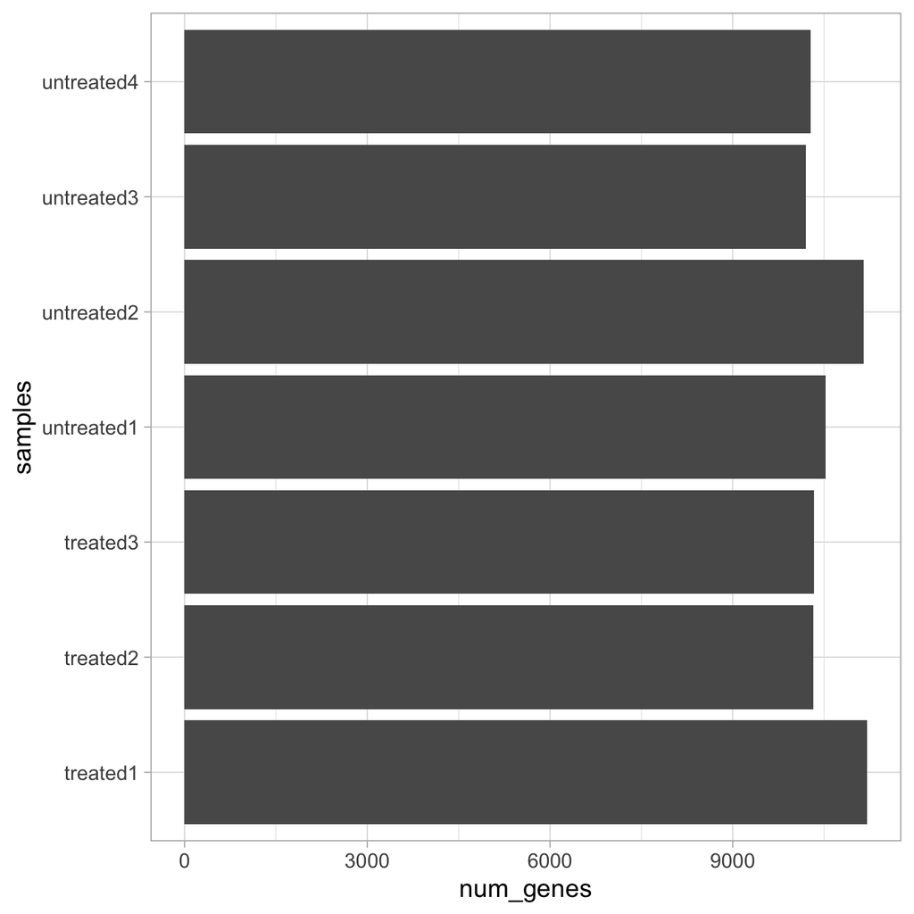

```r
R> data.frame(samples = colnames(se), num_genes = colSums(assay(se) > 0)) %>% ggplot(aes(samples,
+     num_genes)) + geom_bar(stat = "identity") + coord_flip()
```

## PCA

Principal component analysis is a technique to reduce the dimensionality of the data to allow visualization in two dimensions [PCA](https://en.wikipedia.org/wiki/Principal_component_analysis). It takes all the gene abundances for the samples and creates a series of principal components (PCs) to explain the variability in the data. We normally plot the first two PCs for simplicity.

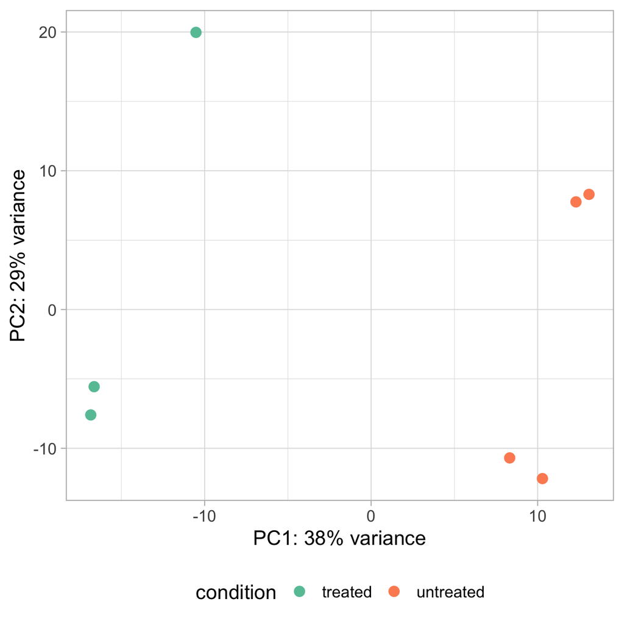

```r
R> assays(se)[["vst"]] = assay(rld)
R>
R> degPCA(assays(se)[[params$slot]], colData(se), condition = params$metadata[1])
```

```r
R> # + ggrepel::geom_text_repel(aes(label=Name)) if you wish to add sample
R> # names
```

# Results

```r
R> # ?degComps: Read how to get the different contrasts for coefficients from
R> # one column: degComps(dds, combs = column_name) for all possible paris:
R> # degComps(dds, combs = column_name, pairs = TRUE) for specific contrasts:
R> # degComps(dds, contrasts = list(c(column_name, group1, group2),
R> # c(column_name, group1, group3)))
R>
R> comparisons = degComps(dds, contrast = contrasts, type = "ashr")
R>
R> save(comparisons, file = file.path(dataDir, "comparisons.rda"))
```

```r
R> lapply(file.path(dataDir, c("dds.rda", "comparisons.rda")), load, environment()) %>%
+     invisible()
```

We performed the analysis using a BH adjusted *P* value cutoff of 0.05 and a log fold-change (LFC) ratio cutoff of 0.

## Alpha level (FDR) cutoffs

Let’s take a look at the number of genes we get with different false discovery rate (FDR) cutoffs. These tests subset *P* values that have been multiple test corrected using the Benjamini Hochberg (BH) method [@Benjamini:1995ws].

```r
R> lapply(names(comparisons), function(x) {
+     cat("### ", x, "\n")
+     degSummary(comparisons[[x]], kable = TRUE) %>% show
+     cat("\n\n")
+ }) %>% invisible()
```

### condition_treated_vs_untreated

|  | 0.1 | 0.05 | 0.01 |
| --- | --- | --- | --- |
| LFC > 0 (up) | LFC > 0 (up) : 613, 5% | LFC > 0 (up) : 481, 3.9% | LFC > 0 (up) : 328, 2.7% |
| LFC < 0 (down) | LFC < 0 (down) : 717, 5.8% | LFC < 0 (down) : 587, 4.7% | LFC < 0 (down) : 403, 3.3% |
| outliers | outliers [1] : 0, 0% | outliers [1] : 0, 0% | outliers [1] : 0, 0% |
| low counts | low counts [2] : 3560, 29% | low counts [2] : 3560, 29% | low counts [2] : 3560, 29% |
| cutoff | (mean count < 4) | (mean count < 4) | (mean count < 4) |
| NULL |  |  |  |

### type_paired-end_vs_single-read

|  | 0.1 | 0.05 | 0.01 |
| --- | --- | --- | --- |
| LFC > 0 (up) | LFC > 0 (up) : 621, 5% | LFC > 0 (up) : 411, 3.3% | LFC > 0 (up) : 192, 1.6% |
| LFC < 0 (down) | LFC < 0 (down) : 657, 5.3% | LFC < 0 (down) : 491, 4% | LFC < 0 (down) : 284, 2.3% |
| outliers | outliers [1] : 0, 0% | outliers [1] : 0, 0% | outliers [1] : 0, 0% |
| low counts | low counts [2] : 3797, 31% | low counts [2] : 3797, 31% | low counts [2] : 3797, 31% |
| cutoff | (mean count < 5) | (mean count < 5) | (mean count < 5) |
| NULL |  |  |  |

# Plots

## Mean average (MA)

An MA plot compares transformed counts on `M` (log ratio) and `A` (mean average) scales [@Yang:2002ty]. Blue arrows represent a correction of the log2 Fold Change values due to variability. Normally this happens when the gene shows high variation and the log2FC is not accurate, here the model tries to estimate them. See this paper for more information:

Love, M.I., Huber, W., Anders, S. (2014) Moderated estimation of fold change and dispersion for RNA-seq data with DESeq2. Genome Biology, 15:550. https://doi.org/10.1186/s13059-014-0550-8

```r
R> lapply(names(comparisons), function(x) {
+     cat("### ", x, "\n")
+     print(degMA(comparisons[[x]], limit = 5))
+     cat("\n\n")
+ }) %>% invisible()
```

### condition_treated_vs_untreated

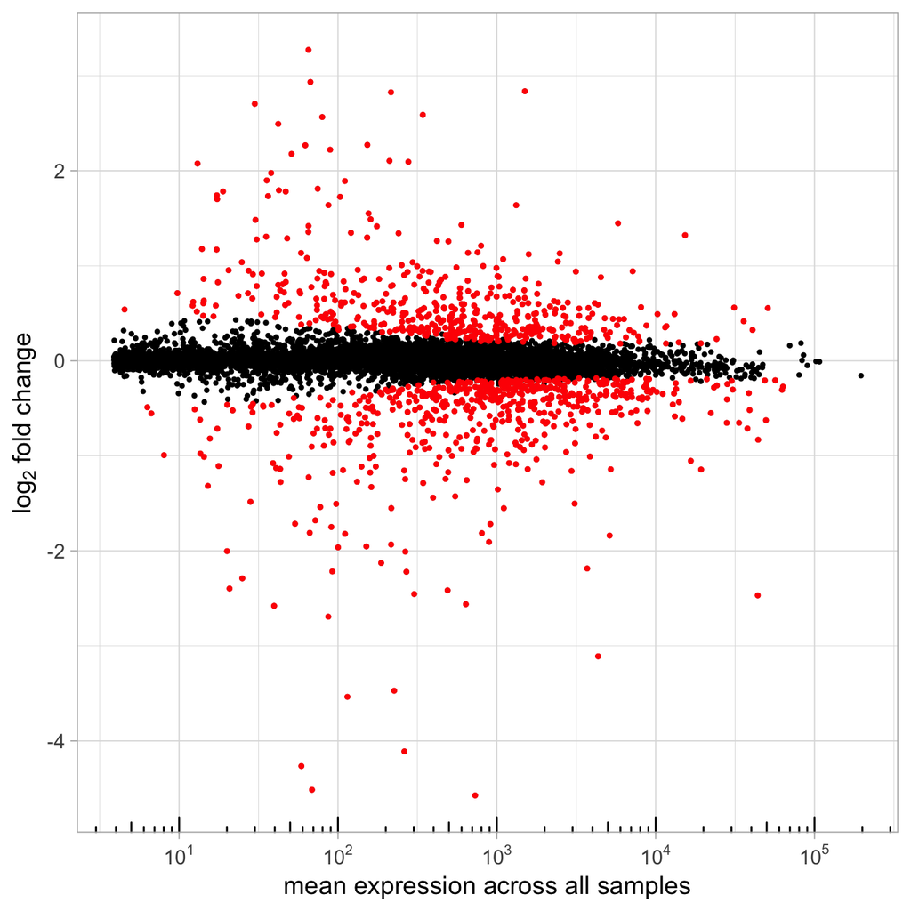

### type_paired-end_vs_single-read

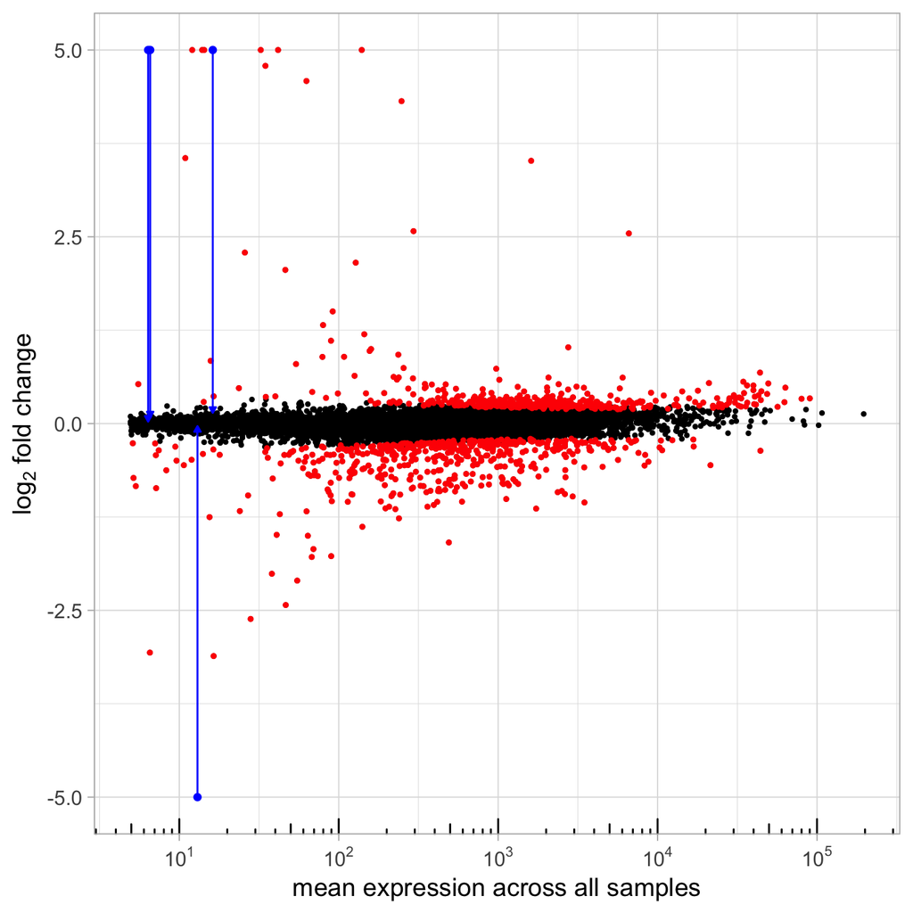

## Volcano

```r
R> lapply(names(comparisons), function(x) {
+     cat("### ", x, "\n")
+     print(degVolcano(comparisons[[x]]))
+     cat("\n\n")
+ }) %>% invisible()
```

### condition_treated_vs_untreated

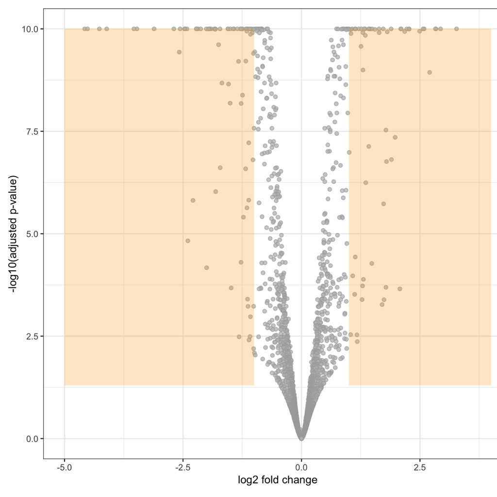

### type_paired-end_vs_single-read

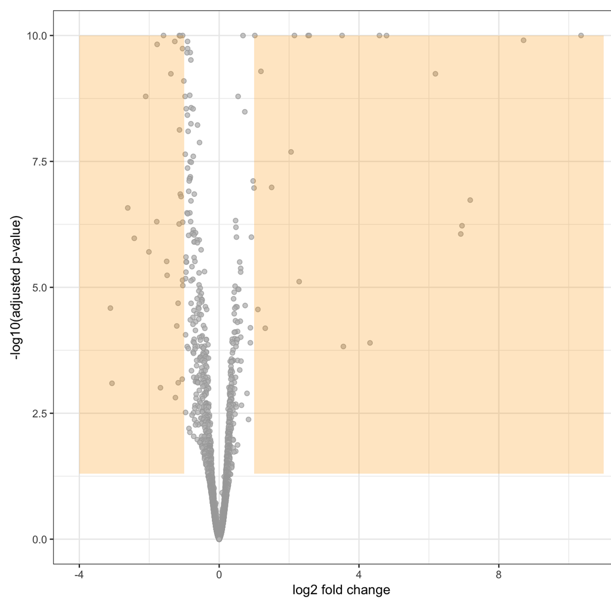

## Heatmap

This plot shows only differentially expressed genes on a per-sample basis. We have scaled the data by row and used the `ward.D2` method for clustering [@WardJr:1963eu].

```r
R> # lapply(names(comparisons), function(x){
R> for (x in names(comparisons)) {
+     cat("### ", x, "\n")
+     s = significants(comparisons[[x]])
+     if (length(s) < 2) {
+         cat("Less than two genes, no possible to plot")
+     } else {
+         p = pheatmap(assays(se)[[params$slot]][s, ], scale = "row", annotation_col = as.data.frame(colData(se)[,
+             params$metadata, drop = F]), show_rownames = FALSE, show_colnames = FALSE,
+             clustering_method = "ward.D2", clustering_distance_cols = "correlation")
+         print(p)
+     }
+     cat("\n\n")
+ }
```

### condition_treated_vs_untreated

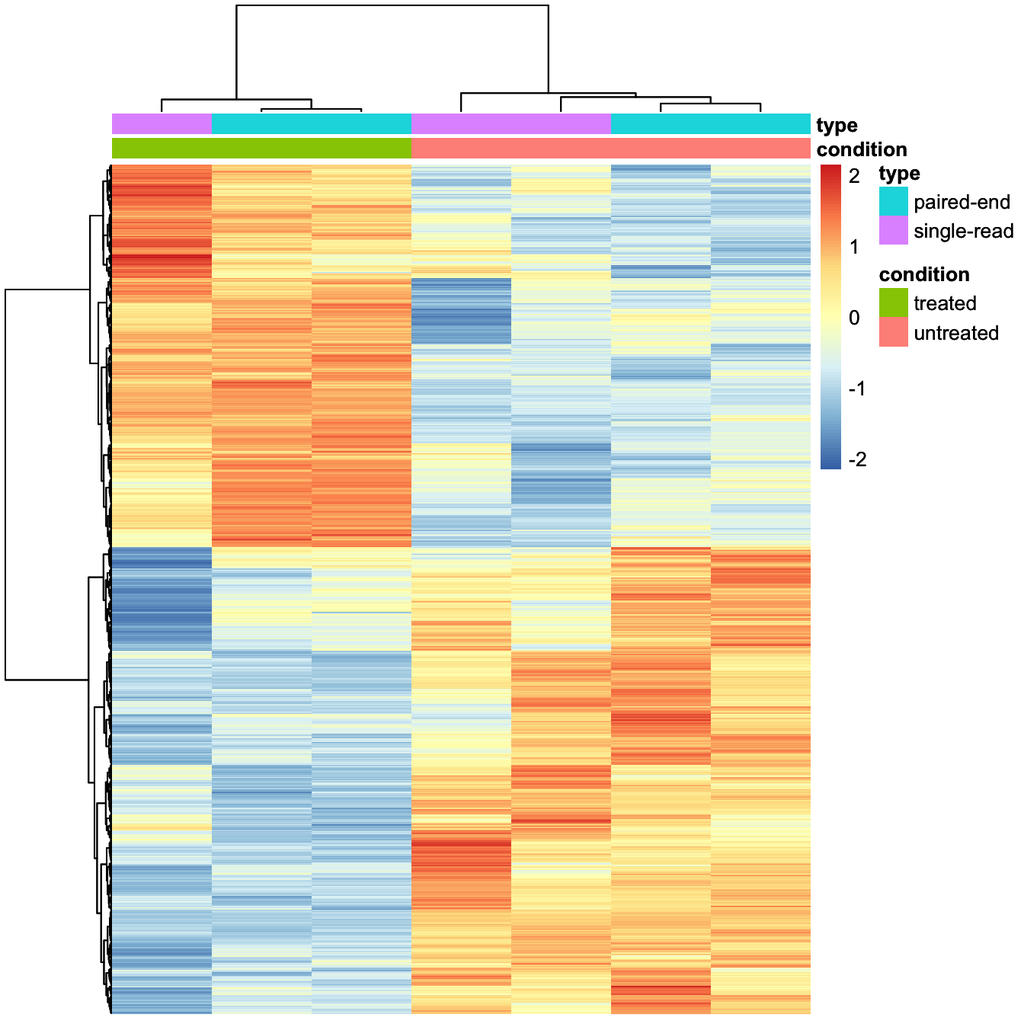

### type_paired-end_vs_single-read

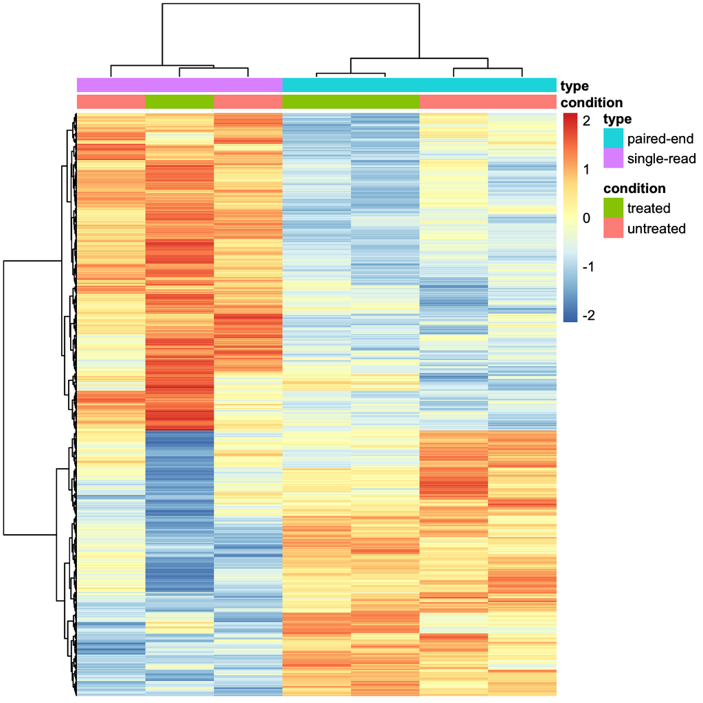

## PCA

Principal component analysis is a technique to reduce the dimensionality of the data to allow visualization in two dimensions [PCA](https://en.wikipedia.org/wiki/Principal_component_analysis). It takes all the gene abundances for the samples and creates a series of principal components (PCs) to explain the variability in the data. We normally plot the first two PCs for simplicity.

```r
R> lapply(names(comparisons), function(x) {
+     cat("### ", x, "\n")
+     s = significants(comparisons[[x]])
+     if (length(s) < 2) {
+         cat("Less than two genes, no possible to plot")
+     } else {
+         degPCA(assays(se)[[params$slot]][s, ], colData(se), condition = params$metadata[1]) %>%
+             print
+
+     }
+     cat("\n\n")
+ }) %>% invisible()
```

### condition_treated_vs_untreated

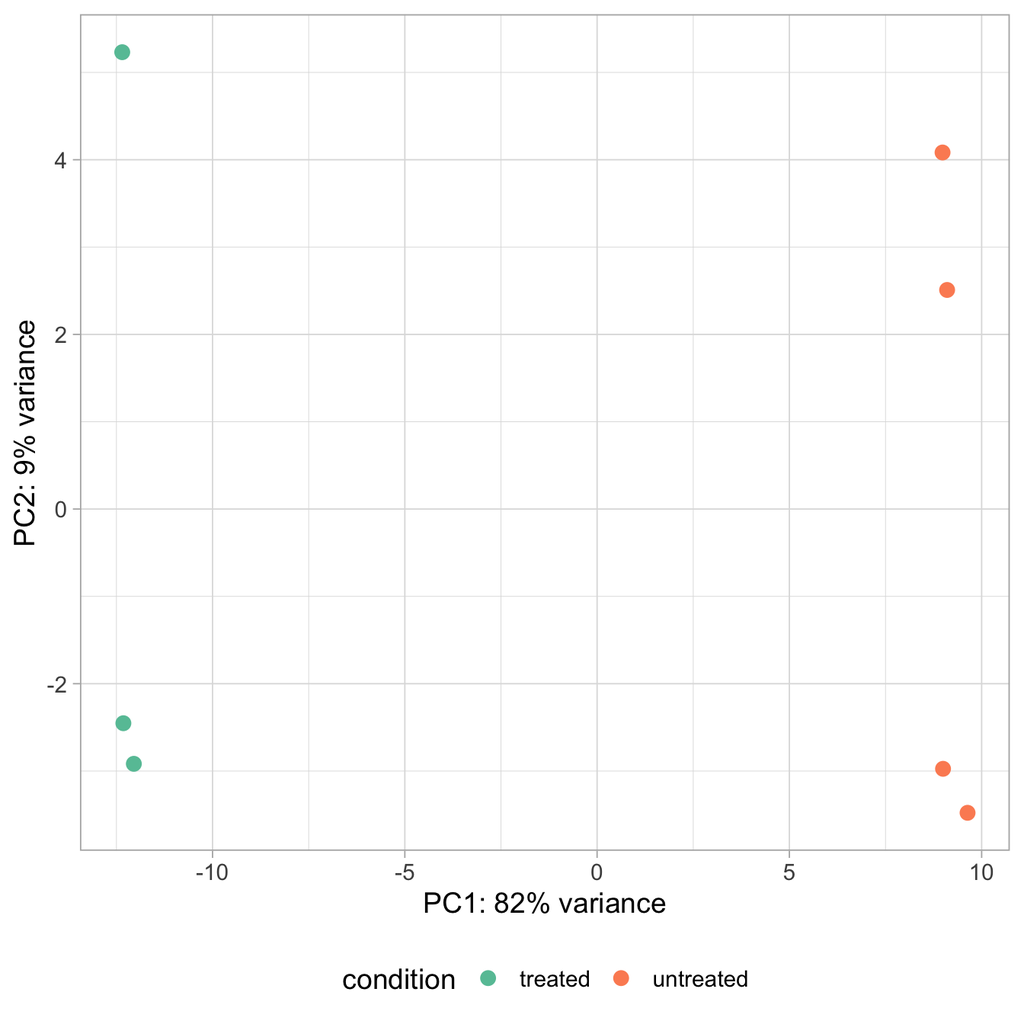

### type_paired-end_vs_single-read

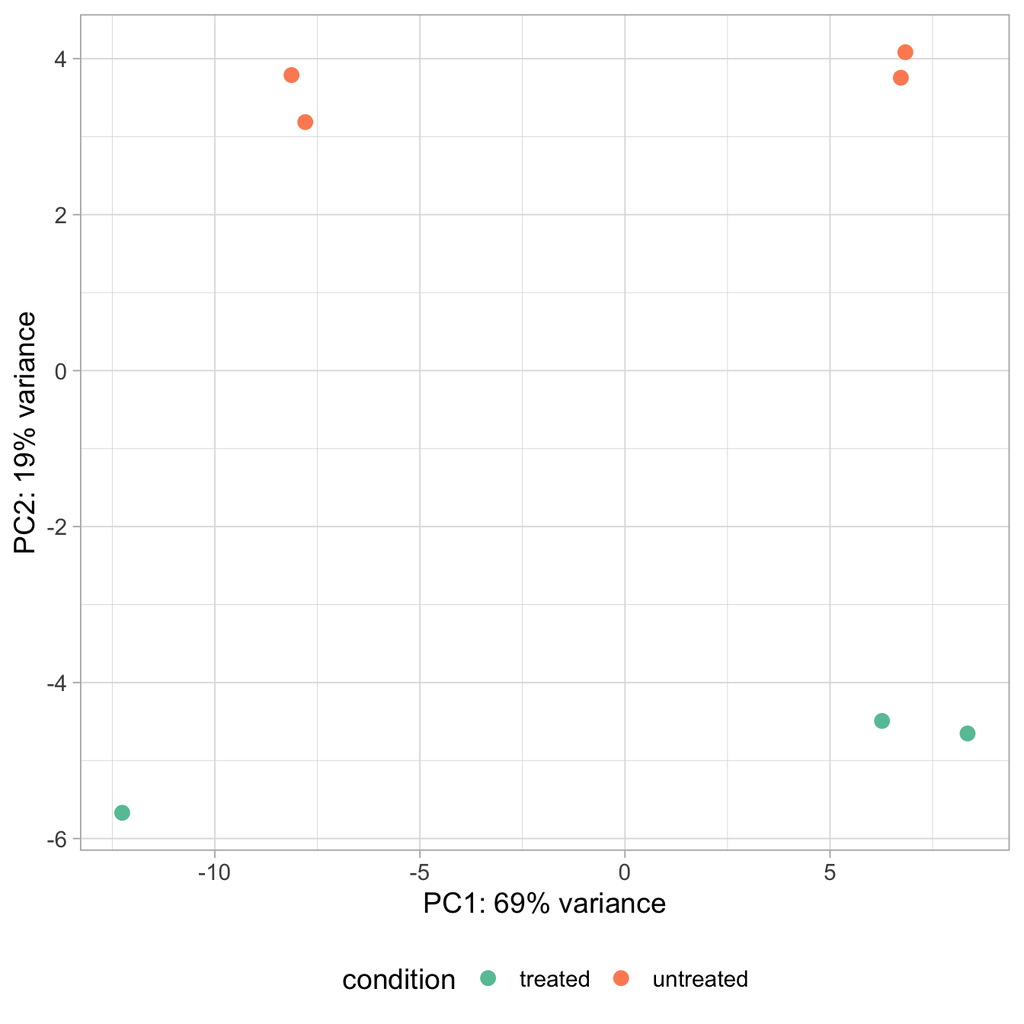

## Gene Expression Patterns

In general, it is useful to cluster the significant genes together in similar patterns across samples. `degPatterns` uses standard expression correlation technique to generate a similarity matrix that can be clustered hierarchically and then split into groups of genes that follow similar expression patterns [degPatterns][].

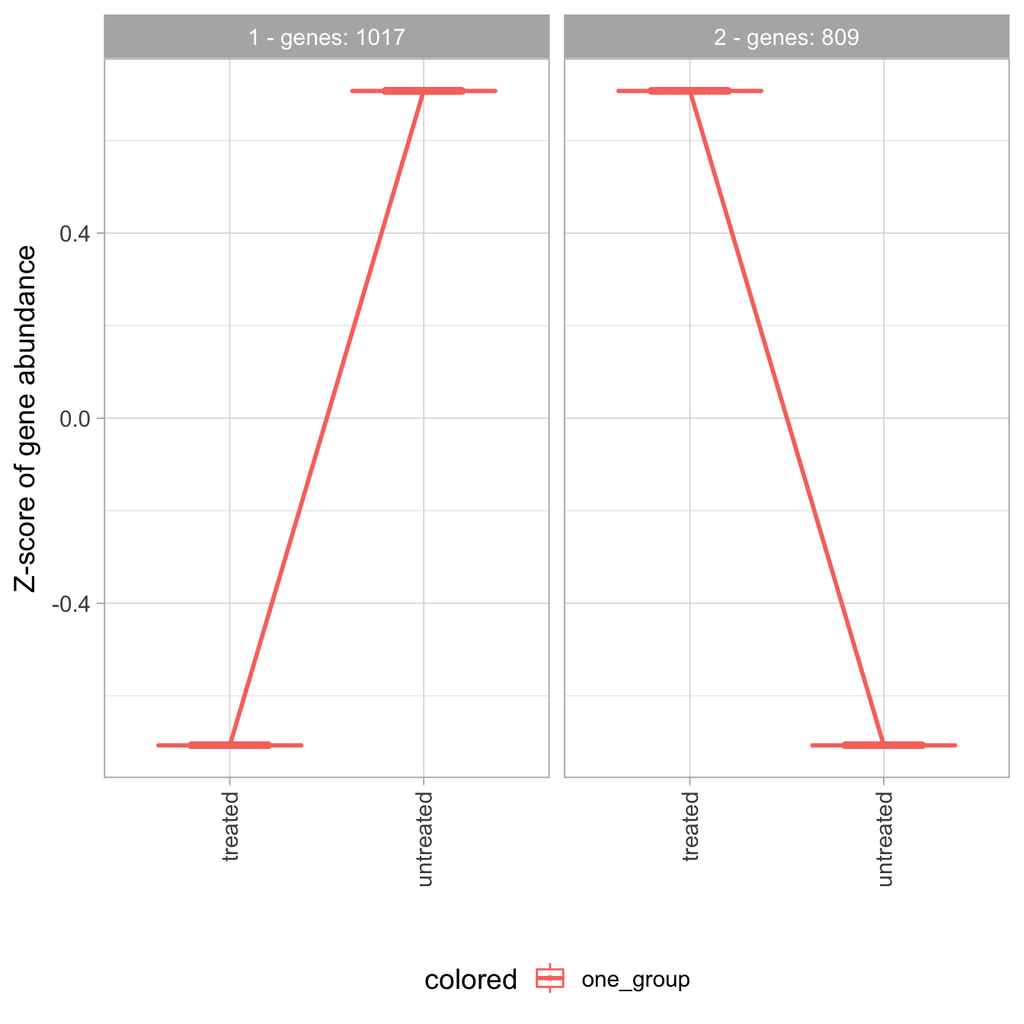

```r
R> # choose the significants genes.  In this case the first is used. `sig`
R> # should be a character vector with genes.
R> sig = significants(comparisons, fc = params$lfc, padj = params$alpha)
R> if (length(sig) > 20) {
+     colData(se)[[params$metadata[1]]] = as.factor(colData(se)[[params$metadata[1]]])
+     pattern = degPatterns(assays(se)[[params$slot]][sig, ], colData(se), time = params$metadata[1],
+         minc = length(sig) * 0.01)
+ } else {
+     cat("Not enough genes to make a pattern analysis.")
+ }
```

## Top genes

```r
R> resTbl = lapply(names(comparisons), function(x) {
+     cat("### ", x, "\n")
+     sign = significants(comparisons[[x]])
+     if (length(sign) == 0) {
+         cat("\n\n**Not significant genes**\n\n")
+         cat("\n\n")
+         return(NULL)
+     }
+     n = min(15, length(sign))
+     p = degPlot(se, genes = sign[1:n], xs = params$metadata[1], slot = params$slot,
+         log2 = FALSE, ann = c("gene_id", "gene_name")) + geom_boxplot(alpha = 0.3) +
+         theme(axis.text.x = element_text(angle = 45, hjust = 0.5, vjust = 0.5))
+     print(p)
+     cat("\n\n")
+     res = deg(comparisons[[x]], tidy = "tibble") %>% left_join(rowData(se) %>%
+         as.data.frame, by = c(gene = "gene_id"))
+     if (exists("pattern"))
+         res = left_join(res, pattern[["df"]], by = c(gene = "genes"))
+     dir.create(file.path(deDir, x), showWarnings = FALSE, recursive = TRUE)
+     write_csv(res, file.path(deDir, x, paste0(x, ".csv.gz")))
+     res
+ })
```

### condition_treated_vs_untreated

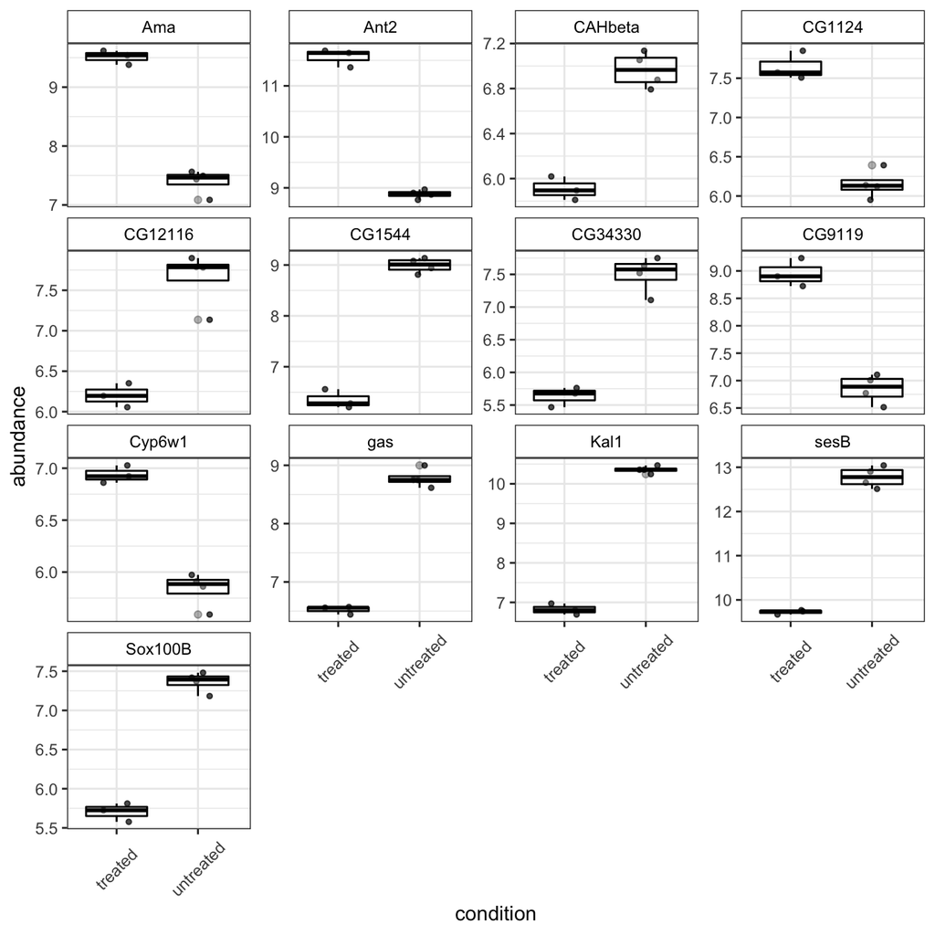

### type_paired-end_vs_single-read

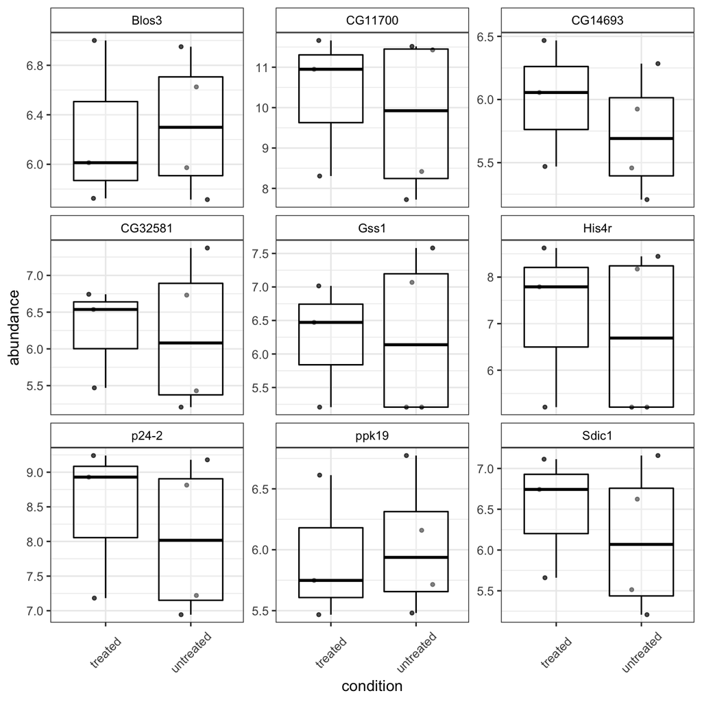

```r
R> names(resTbl) = names(comparisons)
```

## Top tables

Top 10 genes are shown order by False Discovery Rate. Genes below 0.05 are considered significant.

```r
R> lapply(names(resTbl), function(x) {
+     cat("### ", x, "\n")
+     head(resTbl[[x]], 10) %>% kable %>% show
+     cat("\n\n")
+ }) %>% invisible()
```

### condition_treated_vs_untreated

| gene | baseMean | log2FoldChange | lfcSE | pvalue | padj | gene_name | cluster |
| --- | --- | --- | --- | --- | --- | --- | --- |
| FBgn0003360 | 4343.0 | -3.110 | 0.1087 | 0 | 0 | sesB | 1 |
| FBgn0026562 | 43909.3 | -2.468 | 0.0874 | 0 | 0 | SPARC | 1 |
| FBgn0039155 | 730.6 | -4.574 | 0.1661 | 0 | 0 | Kal1 | 1 |
| FBgn0025111 | 1501.4 | 2.837 | 0.1040 | 0 | 0 | Ant2 | 2 |
| FBgn0029167 | 3706.1 | -2.186 | 0.0961 | 0 | 0 | Hml | 1 |
| FBgn0035085 | 638.2 | -2.562 | 0.1290 | 0 | 0 | CG3770 | 1 |
| FBgn0039827 | 261.9 | -4.111 | 0.2161 | 0 | 0 | CG1544 | 1 |
| FBgn0034736 | 225.9 | -3.472 | 0.2049 | 0 | 0 | gas | 1 |
| FBgn0029896 | 489.9 | -2.415 | 0.1475 | 0 | 0 | CG3168 | 1 |
| FBgn0000071 | 342.2 | 2.588 | 0.1583 | 0 | 0 | Ama | 2 |

### type_paired-end_vs_single-read

| gene | baseMean | log2FoldChange | lfcSE | pvalue | padj | gene_name | cluster |
| --- | --- | --- | --- | --- | --- | --- | --- |
| FBgn0003943 | 6603.89 | 2.545 | 0.0989 | 0 | 0 | Ubi-p63E | 2 |
| FBgn0053105 | 294.59 | 2.575 | 0.1783 | 0 | 0 | p24-2 | 2 |
| FBgn0029856 | 1610.61 | 3.517 | 0.3350 | 0 | 0 | CG11700 | 2 |
| FBgn0083990 | 62.72 | 4.585 | 0.4321 | 0 | 0 | NA | 2 |
| FBgn0086558 | 2752.52 | 1.020 | 0.0990 | 0 | 0 | Ubi-p5E | 2 |
| FBgn0028430 | 1730.86 | -1.138 | 0.1148 | 0 | 0 | He | 1 |
| FBgn0030755 | 127.86 | 2.154 | 0.2290 | 0 | 0 | NA | 2 |
| FBgn0037913 | 490.73 | -1.591 | 0.1956 | 0 | 0 | fabp | 2 |
| FBgn0039914 | 593.37 | -1.045 | 0.1176 | 0 | 0 | mav | 1 |
| FBgn0053909 | 139.45 | 10.353 | 1.1838 | 0 | 0 | His4r | 2 |

# File downloads

The results are saved as gzip-compressed comma separated values (CSV). Gzip compression is natively supported on [macOS](https://www.apple.com/macos) and Linux-based operating systems. If you’re running Windows, we recommend installing [7-Zip](http://www.7-zip.org). CSV files can be opened in [Excel](https://products.office.com/en-us/excel) or [RStudio](https://www.rstudio.com).

## Differential expression tables

# Methods

RNA-seq counts were generated by [bcbio](https://github.com/chapmanb/bcbio-nextgen) using salmon [@salmon]. Counts were imported into [R](https://www.r-project.org) using [tximport](https://bioconductor.org/packages/release/bioc/html/tximport.html) [@tximport] and [DESeq2](https://bioconductor.org/packages/release/bioc/html/DESeq2.html) [@DESeq2]. Gene annotations were obtained from [Ensembl](http://useast.ensembl.org). Plots were generated by [ggplot2](http://ggplot2.org) [@ggplot2]. Heatmaps were generated by [pheatmap](https://cran.r-project.org/web/packages/pheatmap/index.html) [@pheatmap].

```r
R> print(params)
```

```
## $se_file
## [1] "data/se.rds"
##
## $design
## [1] "~ type + condition"
##
## $contrast
## [1] "condition.treated_vs_untreated,type.paired-end_vs_single-read"
##
## $metadata
## [1] "condition" "type"
##
## $alpha
## [1] 0.05
##
## $lfc
## [1] 0
##
## $slot
## [1] "vst"
##
## $cache_dir
## [1] "../cache"
##
## $cache_on
## [1] FALSE
##
## $output_dir
## [1] "/Users/lpantano/repos/pilm/templates-rmd-de/docs/de"
```